# Assignment2

Chloe Hsieh

2023-05-01

# **Q1**

## **Training data**

```r
library(hetGP)

set.seed(123)
#define the Borehole function
borehole = function(xx){ #  BOREHOLE FUNCTION d=8
  mini = c(0.05,100,63070,990,63.1,700,1120,9855)
  maxi = c(0.15,50000,115600,1110,116,820,1680,12045)
  rw <- mini[1] + xx[1]*(maxi[1] - mini[1])
  r  <- mini[2] + xx[2]*(maxi[2] - mini[2])
  Tu <- mini[3] + xx[3]*(maxi[3] - mini[3])
  Hu <- mini[4] + xx[4]*(maxi[4] - mini[4])
  Tl <- mini[5] + xx[5]*(maxi[5] - mini[5])
  Hl <- mini[6] + xx[6]*(maxi[6] - mini[6])
  L  <- mini[7] + xx[7]*(maxi[7] - mini[7])
  Kw <- mini[8] + xx[8]*(maxi[8] - mini[8])
  frac1 <- 2 * pi * Tu * (Hu-Hl)
  frac2a <- 2*L*Tu / (log(r/rw)*rw^2*Kw)
  frac2b <- Tu / Tl
  frac2 <- log(r/rw) * (1+frac2a+frac2b)
  y <- frac1 / frac2
  return(y)
}

#generate training data
num_train_samples <- 1000
X_train <- matrix(runif(num_train_samples * 8), ncol = 8)
y_train <- apply(X_train, 1, borehole)
sigma <- sqrt(var(y_train) / 5)  # Variance for SNR=5
error <- rnorm(num_train_samples, mean = 0, sd = sigma)
y_train <- y_train + error

head(X_train)
```

```
##           [,1]      [,2]      [,3]      [,4]      [,5]       [,6]       [,7]
## [1,] 0.2875775 0.2736227 0.1596740 0.2058269 0.3044642 0.24862988 0.44026102
## [2,] 0.7883051 0.5938669 0.1445159 0.9425390 0.8328188 0.98946318 0.39739215
## [3,] 0.4089769 0.1601848 0.1491804 0.3793238 0.5936475 0.71712190 0.37154765
## [4,] 0.8830174 0.8534302 0.5144343 0.6262401 0.8071966 0.65172829 0.52880857
## [5,] 0.9404673 0.8477392 0.4928273 0.1835024 0.2940508 0.24055621 0.07378541
## [6,] 0.0455565 0.4778868 0.6163428 0.6592076 0.1410852 0.08679275 0.71684977
##            [,8]
## [1,] 0.93034086
## [2,] 0.59104489
## [3,] 0.07974532
## [4,] 0.84501857
## [5,] 0.02978437
## [6,] 0.81465972
```

```r
#calculate mean of training outputs
y_train_mean <- mean(y_train)

#fit GP model
GPmodel <- mleHomGP(X_train, y_train)
summary(GPmodel)
```

```
## N =  1000  n =  1000  d =  8
## Gaussian  covariance lengthscale values:  0.7245832 3.336997 3.322085 3.34413 3.341974 2.971995 3.327023 3.329708
## Homoskedastic nugget value:  0.3150111
## Variance/scale hyperparameter:  1256.758
## Estimated constant trend value:  81.61025
## MLE optimization:
##  Log-likelihood =  -4483.302 ; Nb of evaluations (obj, gradient) by L-BFGS-B:  38 38 ; message:  CONVERGENCE: REL_REDUCTION_OF_F <= FACTR*EPSMCH
```

We used the hetGP (Heteroskedastic Gaussian Process Modeling and Design under Replication) package’s mleHomGP function to fit a GP model. This choice was driven by including a consistent error term (noise) setting in the training data. The model is based on Gaussian process regression under homoskedastic noise, with hyperparameters estimated via maximum likelihood. We employs the default Gaussian kernel $c(x, y) = exp(−(x − y)^2/theta)$. We have 1000 unique data points.

The Gaussian covariance lengthscale values $\theta = {\theta_{1},\cdots,\theta_{8}}= \{0.7245832, 3.336997, 3.322085, 3.34413, 3.341974, 2.971995, 3.327023, 3.329708\}$. These lengthscales control the smoothness of the Gaussian process and correspond to the parameters in the borehole function. When transformed back to $\xi$, smaller values indicate that the process varies more rapidly in that dimension. The model’s hyperparameters are $\sigma^2 = 1256.758,$ representing the variance or scale of the GP, and $\hat{\beta} = 81.61025$.

## **Testing data**

```r
set.seed(0)
# Generate testing dataset
num_test_samples <- 100000
X_test <- matrix(runif(num_test_samples * 8), ncol = 8)
y_test <- apply(X_test, 1, borehole)

head(X_test)
```

```
##           [,1]      [,2]      [,3]      [,4]      [,5]      [,6]      [,7]
## [1,] 0.8966972 0.1231141 0.9742796 0.3310831 0.2814200 0.2206980 0.7106411
## [2,] 0.2655087 0.7005180 0.7856568 0.2316306 0.5902861 0.4057251 0.2931432
## [3,] 0.3721239 0.7017648 0.5254272 0.2801941 0.7229230 0.2745413 0.7568588
## [4,] 0.5728534 0.3129363 0.6525329 0.5992403 0.2107272 0.6334162 0.9850445
## [5,] 0.9082078 0.5523553 0.7551247 0.1812997 0.4835402 0.2974635 0.1516232
## [6,] 0.2016819 0.8724921 0.7487606 0.2604501 0.6739571 0.7777561 0.5460846
##           [,8]
## [1,] 0.5060545
## [2,] 0.5192359
## [3,] 0.3269390
## [4,] 0.1247825
## [5,] 0.1153597
## [6,] 0.7119584
```

```r
# Predict outputs using the trained GPR model
y_hat <- predict(x = X_test, object = GPmodel)
y_pred <- y_hat$mean

# Calculate normalized RMSPE
# Function to calculate normalized RMSPE
normalized_rmspe <- function(y_test, y_pred, y_train_mean) {
  numerator <- sum((y_pred - y_test)^2)
  denominator <- sum((y_train_mean - y_test)^2)
  return(sqrt(numerator / denominator))
}

rmspe <- normalized_rmspe(y_test, y_pred, y_train_mean)
print(paste("Normalized RMSPE:", rmspe))
```

```
## [1] "Normalized RMSPE: 0.116843642288521"
```

The Normalized RMSPE is 0.116843642288521, indicating a good model performance.

## **Plot**

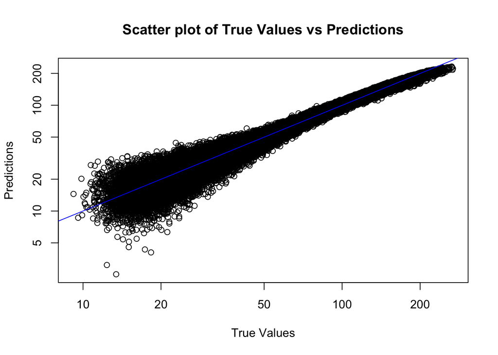

```r
# Create scatter plot
plot(y_test, y_pred, log = "xy", xlab = "True Values", ylab = "Predictions", main = "Scatter plot of True Values vs Predictions")

# Plot identity line
abline(0, 1, col = 'blue')
```

```r
# Set aspect ratio to be equal
aspect_ratio <- diff(range(y_pred)) / diff(range(y_test))
asp <- aspect_ratio / par("pin")[2] * par("pin")[1]
#par(asp = asp)
```

The plot shows that the points follow the diagonal line, indicating a good prediction of the fitted GP model.